# Regresion Lineal Multiple

Andrea Pérez

2 de agosto de 2015

Las datas con las cuales vamos hacer nuestro analisis son: poblacion1 y poblacion2, que se muestran a continuacion.

```r
library(readxl)
po1<-sdata <- read_excel("poblacion1.xlsx",sheet = 1,col_names = TRUE, na=c(""))
po1
```

```
##    identificador poblacion var.pobl.mayor menores.18
## 1           1001      18.7            6.2       39.7
## 2           1002      13.8            7.2       10.4
## 3           1003      13.4            7.1       20.4
## 4           1004      11.4            2.6       38.7
## 5           1005      10.5            2.8       36.4
## 6           1006      10.3            1.4       29.8
## 7           1007      10.3           -0.5       31.8
## 8           1008      10.3            3.0       31.1
## 9           1009      10.3           -1.9       15.9
## 10          1010       9.4           -1.5       22.4
## 11          1011       9.4            4.6       36.0
## 12          1012       9.3            4.9       34.9
## 13          1013       8.5           -0.7       28.1
## 14          1014       8.5            4.8       32.8
```

[output cut: 30 more lines]

```r
po2<-sdata <- read_excel("poblacion2.xlsx",sheet = 1,col_names = TRUE, na=c(""))
po2
```

```
##    identificador part.almz.escl var.ingresos tasa.crimen var.tasa.crimen
## 1           1044           73.8         50.5       704.1           -40.9
## 2           1042           34.4         24.2       179.9            12.3
## 3           1010           22.2         33.5        61.5           -32.7
## 4           1009           39.9         38.5        86.4           -13.5
## 5           1008           51.7         26.2        42.4           -31.9
## 6           1007           57.2         27.2        61.2           -17.6
## 7           1006           43.7         29.4        54.0           -10.0
## 8           1005           72.3         26.0        77.5           -21.6
## 9           1004           78.2         18.4        86.6           -12.8
## 10          1003           13.9         22.5        38.3           -33.6
## 11          1002           57.9         26.2       111.0           -22.6
## 12          1001           55.8         28.7        52.6            -2.9
## 13          1031           64.9         21.7       139.9           -35.0
## 14          1029           17.4         14.7       132.1            -8.1
```

[output cut: 67 more lines]

```r
dim(po1)
```

```
## [1] 44  4
```

```r
dim(po2)
```

```
## [1] 40  7
```

Como podemos observar, la data población1 contiene 44 observaciones de 4 variables. La data población2 contiene 40 observaciones de 7 variables.

Ahora mediante la funcion match, uniremos las dos poblaciones en una sola data que se llamara poblacion.

```r
pobla<-match(po1$identificador,po2$identificador)
poblacion1<-cbind(po1,po2[pobla,])
poblacion1
```

```
##      identificador poblacion var.pobl.mayor menores.18 identificador
## 12            1001      18.7            6.2       39.7          1001
## 11            1002      13.8            7.2       10.4          1002
## 10            1003      13.4            7.1       20.4          1003
## 9             1004      11.4            2.6       38.7          1004
## 8             1005      10.5            2.8       36.4          1005
## 7             1006      10.3            1.4       29.8          1006
## 6             1007      10.3           -0.5       31.8          1007
## 5             1008      10.3            3.0       31.1          1008
## 4             1009      10.3           -1.9       15.9          1009
## 3             1010       9.4           -1.5       22.4          1010
## 30            1011       9.4            4.6       36.0          1011
## 29            1012       9.3            4.9       34.9          1012
## 28            1013       8.5           -0.7       28.1          1013
## 27            1014       8.5            4.8       32.8          1014
```

[output cut: 120 more lines]

```r
poblacion<-poblacion1[c(-24,-25,-30,-43),]
```

Luego identificaremos la clase de cada variable y genereraremos diagramas de cajas para variables continuas y diagramas de barras para variables discretas.

```r
for(i in 1:ncol(poblacion)) {
     print(class(poblacion[,i]))
}
```

```
## [1] "numeric"
## [1] "numeric"
## [1] "numeric"
## [1] "numeric"
## [1] "numeric"
## [1] "numeric"
## [1] "numeric"
## [1] "numeric"
## [1] "numeric"
## [1] "character"
## [1] "character"
```

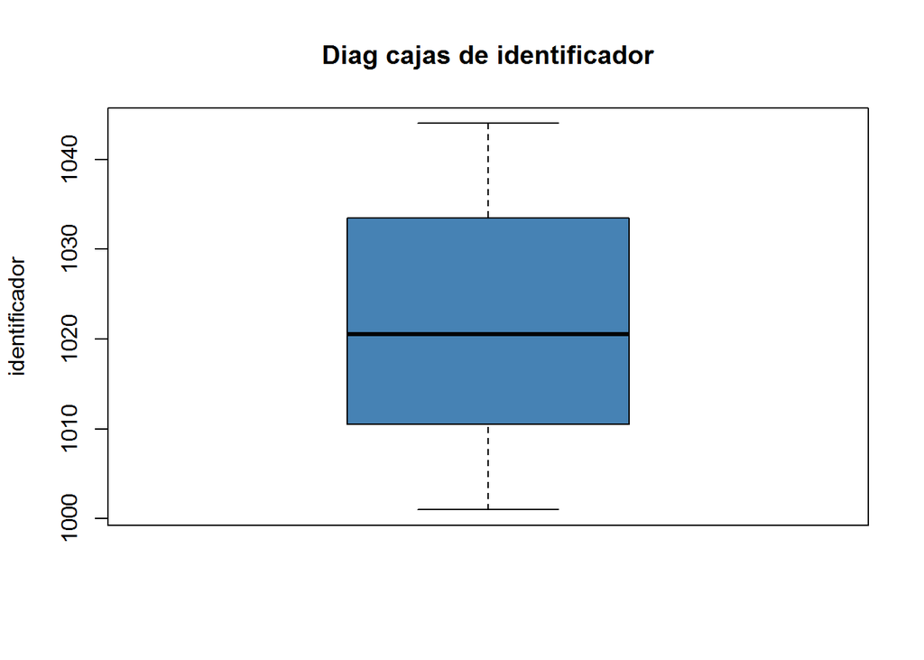

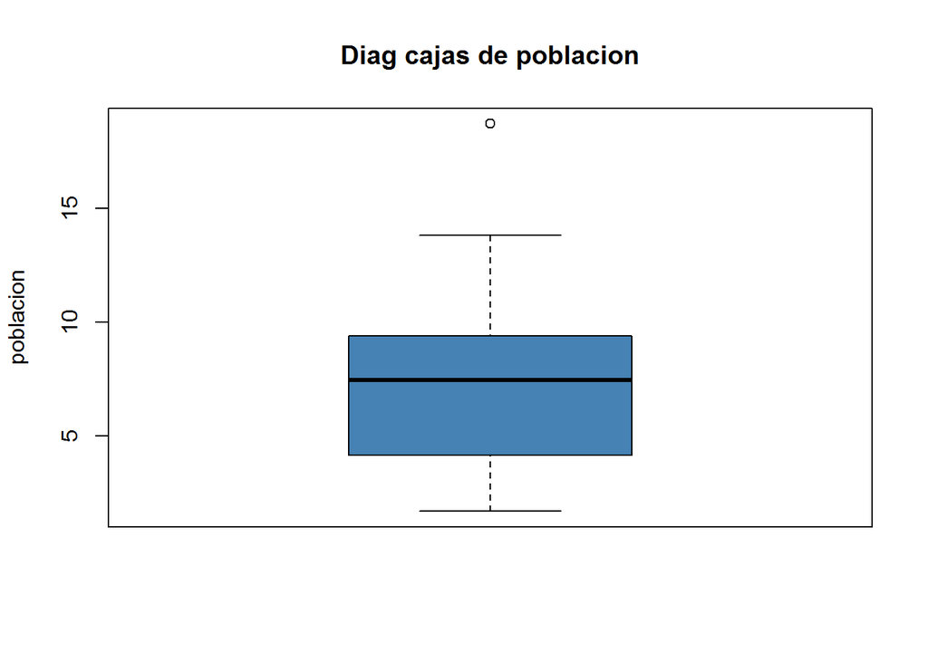

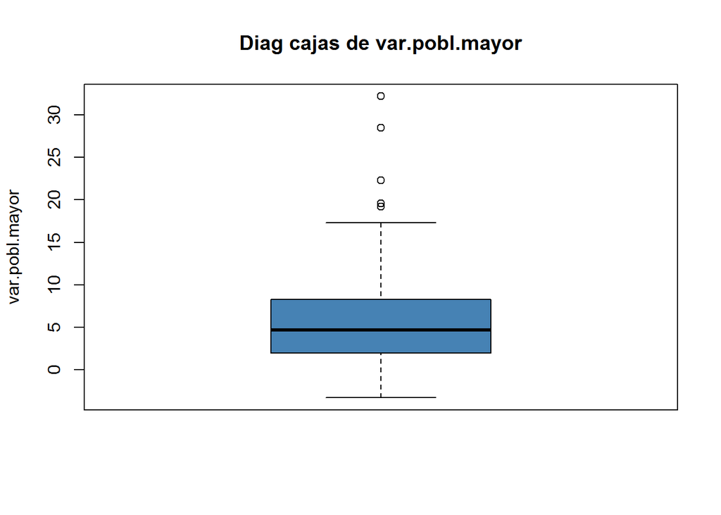

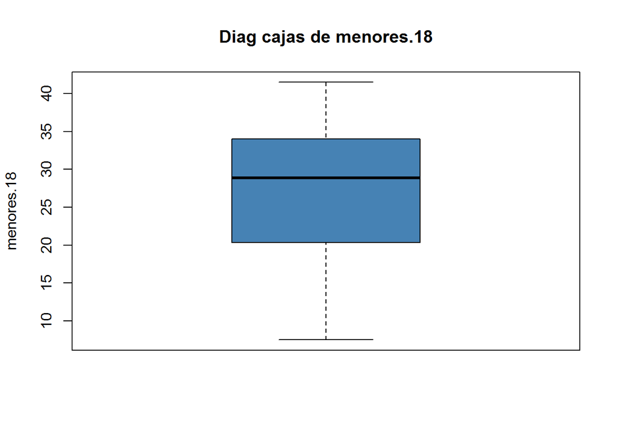

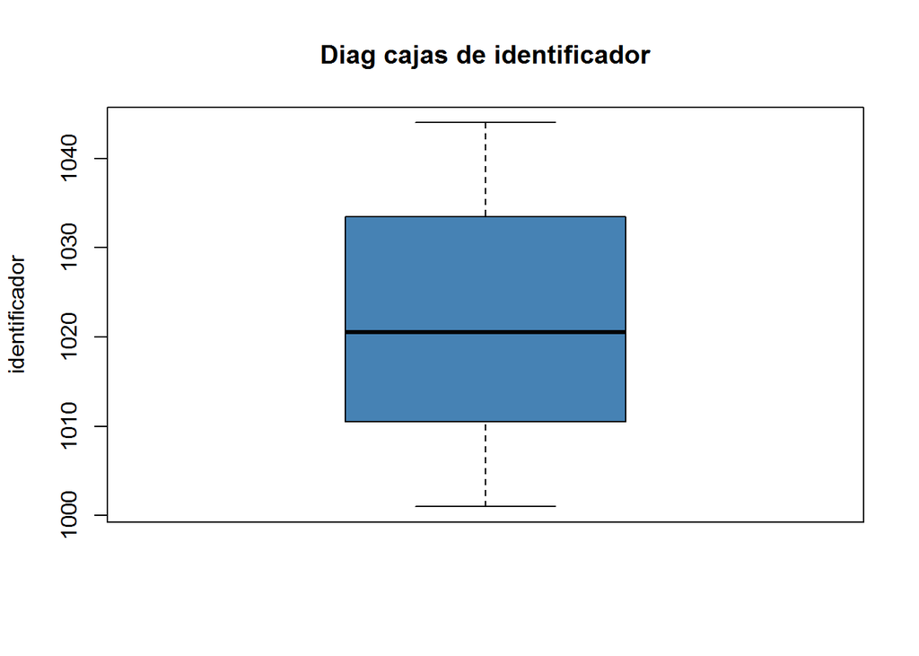

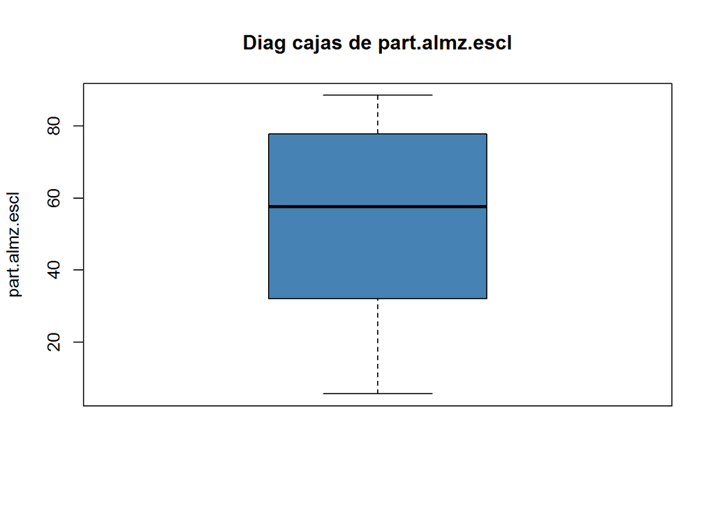

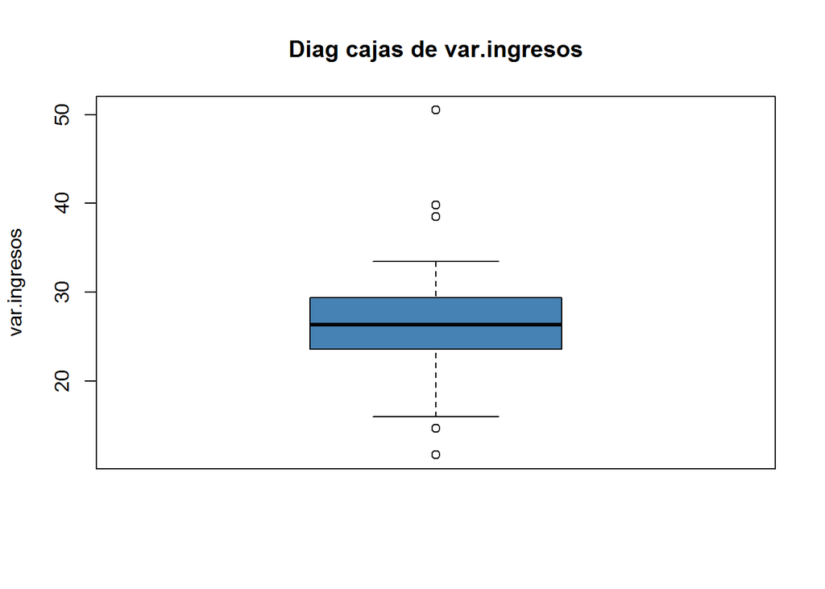

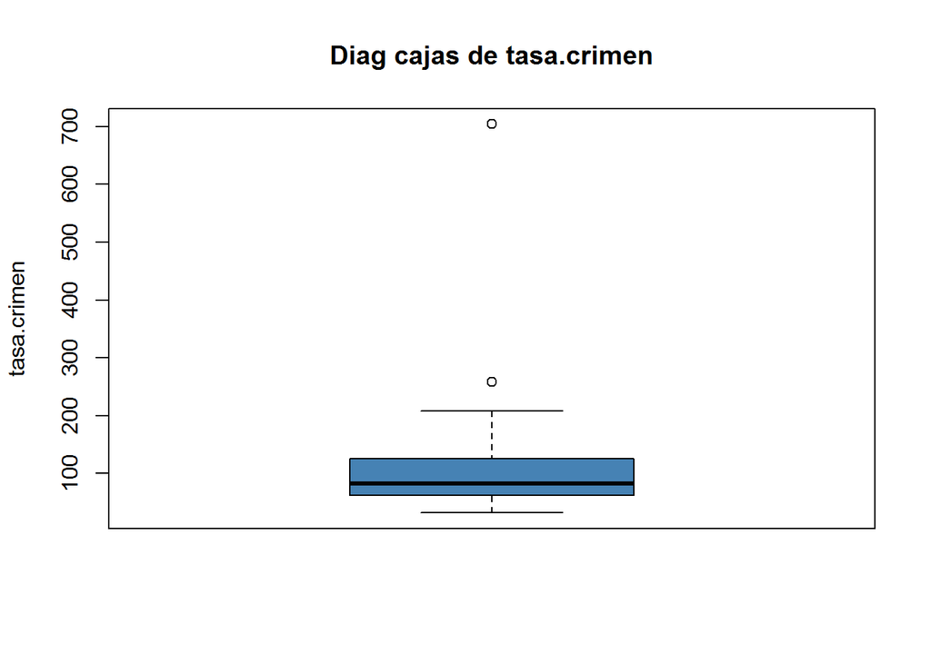

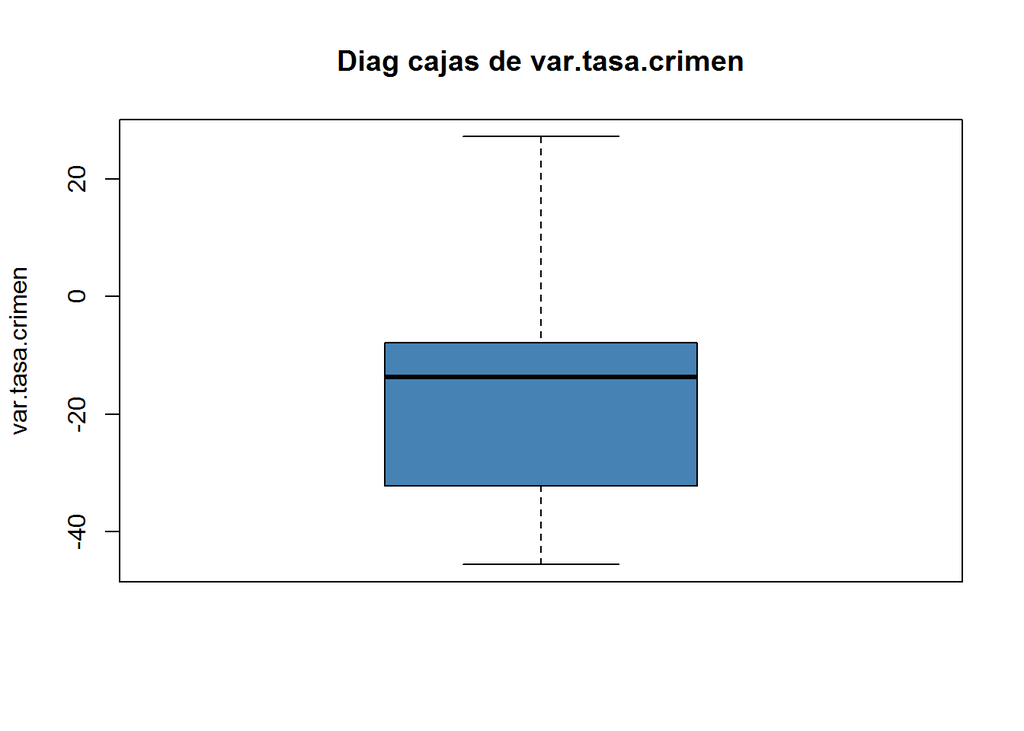

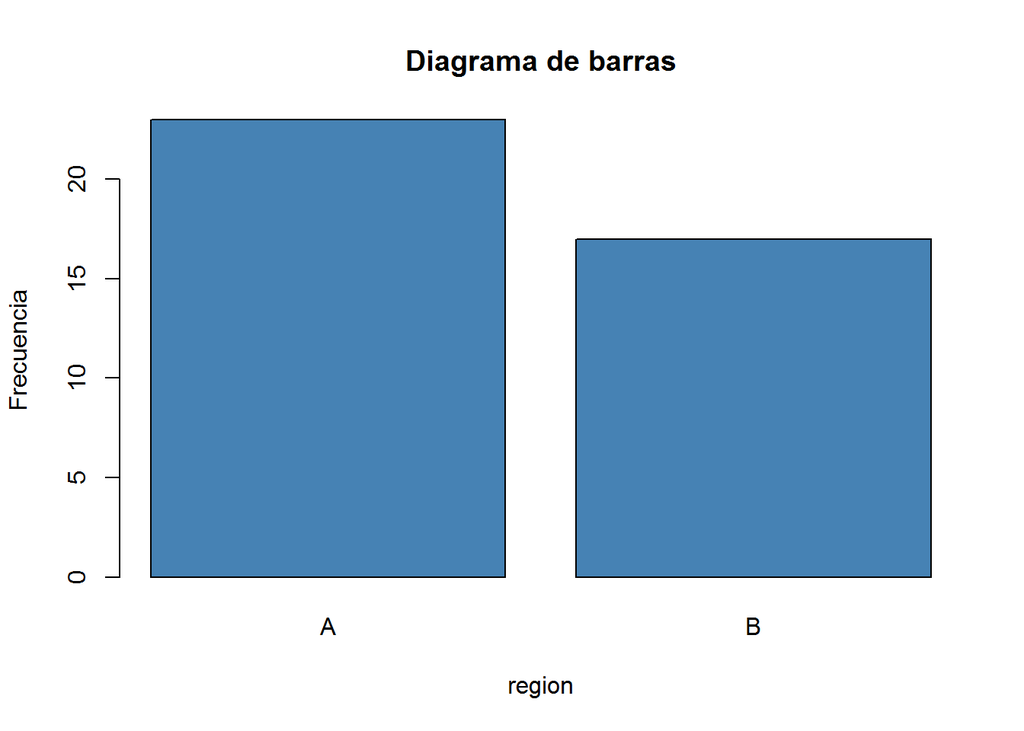

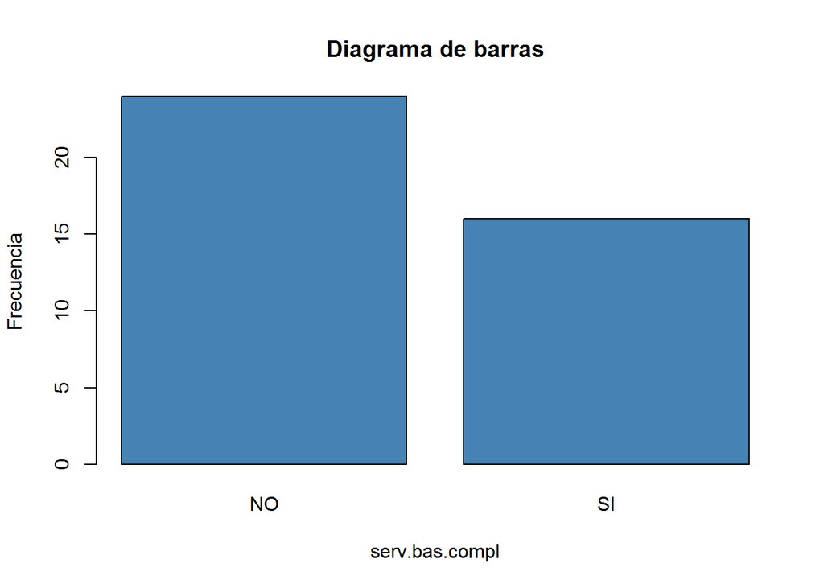

```r
for(i in 1:ncol(poblacion)) {
if(is.numeric(poblacion[,i])){
boxplot(poblacion[,i], xlab = "", ylab=names(poblacion)[i], main=paste("Diag cajas de",names(poblacion)[i]),
        col="steelblue", border="gray1")
}else{
    barplot(table(poblacion[,i]), xlab = names(poblacion)[i], ylab="Frecuencia", main="Diagrama de barras",
            col="steelblue", border="gray1")
 }
}
```